# Tree-based Machine Learning Model

Tiara Dwiputri

November 14, 2019

# A Model to Kickstart your Modelling Practices

## Why Should You Learn This

As machine learning is more commonly adopted in the industry, you will be soon exposed to a **tree-based model**. The algorithm for creating a tree-based model generates a set of rules by learning from historical data. Let’s start with a simple example.

# Motivational Example: Where do you want to eat?

## Given a sample dataset

| budget | review_based | adventurous | has_recommendation | choice |
| --- | --- | --- | --- | --- |
| 19978.08 | 0 | 1 | 0 | food court |
| 26315.31 | 0 | 1 | 1 | restaurant |
| 24210.83 | 0 | 0 | 1 | food court |
| 33867.85 | 0 | 0 | 1 | food court |
| 26169.71 | 0 | 1 | 0 | restaurant |
| 28186.30 | 0 | 1 | 1 | restaurant |

The data is provided under `data_input` folder within the git repository.

## Building A Decision Tree

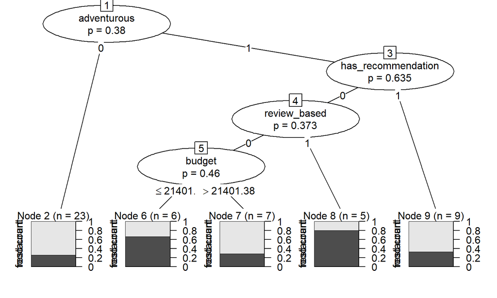

## Interpreting The Rules

```
##
## Model formula:
## choice ~ budget + review_based + adventurous + has_recommendation
##
## Fitted party:
## [1] root
## |   [2] adventurous in 0: food court (n = 23, err = 26.1%)
## |   [3] adventurous in 1
## |   |   [4] has_recommendation in 0
## |   |   |   [5] review_based in 0
## |   |   |   |   [6] budget <= 21401.37869: restaurant (n = 6, err = 33.3%)
## |   |   |   |   [7] budget > 21401.37869: food court (n = 7, err = 28.6%)
## |   |   |   [8] review_based in 1: restaurant (n = 5, err = 20.0%)
## |   |   [9] has_recommendation in 1: food court (n = 9, err = 33.3%)
##
## Number of inner nodes:    4
## Number of terminal nodes: 5
```

# Automatic Feature Selection

## Understanding Entropy

$E = \sum_{i=1}^{n}-p_i \times log_2(p_i)$

$n$ is number of existing class on target variable  
$p_i$ is number of class proportion

Entropy is a measurement of a class heterogenity. A set of target variable that has 50-50 class proportion the most heterogen, resulting in $E = 1$, any different proportion will results in entropy lesser than 1.

## Picking ‘Most Informative’ Predictor

Recall how our decision tree picked `adventurous` as the first rules. The general algorithm of tree-based model can be described as follow:  
1. Prepare all rule possibility on the current node  
2. Calculate the entropy for current node  
3. Split the data based on all possible rule from step 1  
4. Calculate entropy for all split results  
5. Calculate entropy difference from initial node to split result (commonly known as **information gain**)  
6. Pick the rule that results in a largest information gain

## Glimpsing Our Data

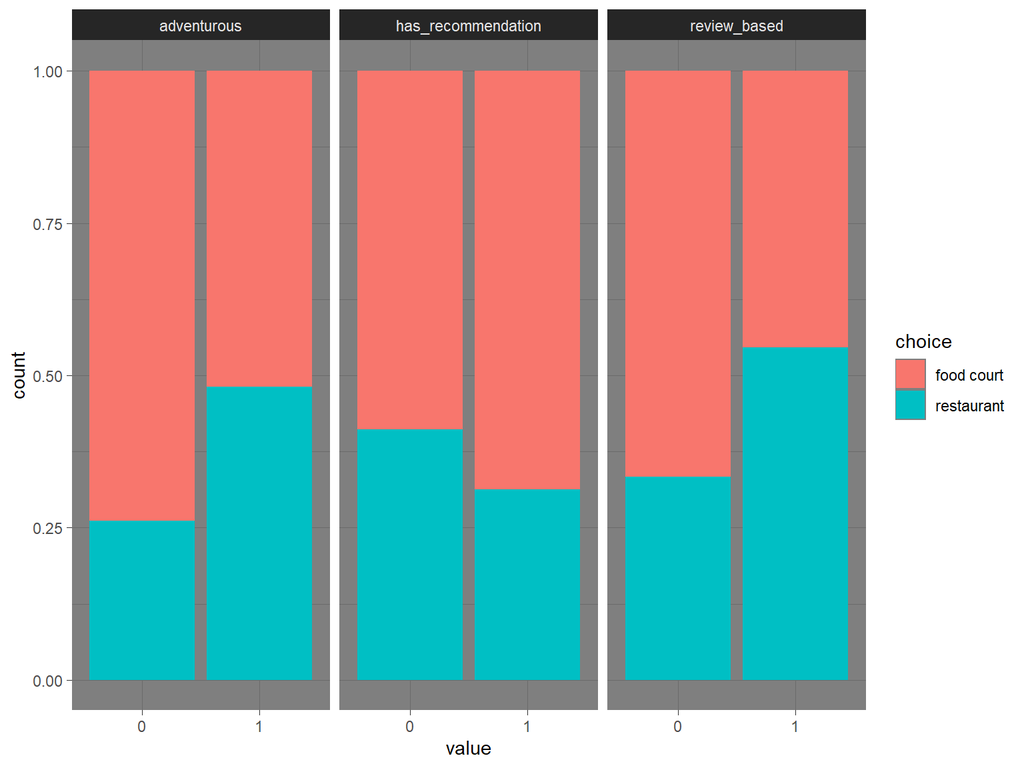

## What we have covered so far

- Rule based model
- Entropy and information gain
- Automatic Feature selection

# Knowledge Check

###### Question 1

1. Given the following dataset:

```
## Observations: 891
## Variables: 6
## $ Survived <int> 0, 1, 1, 1, 0, 0, 0, 0, 1, 1, 1, 1, 0, 0, 0, 1, 0, 1,...
## $ Pclass   <int> 3, 1, 3, 1, 3, 3, 1, 3, 3, 2, 3, 1, 3, 3, 3, 2, 3, 2,...
## $ Sex      <fct> male, female, female, female, male, male, male, male,...
## $ Age      <dbl> 22, 38, 26, 35, 35, NA, 54, 2, 27, 14, 4, 58, 20, 39,...
## $ SibSp    <int> 1, 1, 0, 1, 0, 0, 0, 3, 0, 1, 1, 0, 0, 1, 0, 0, 4, 0,...
## $ Fare     <dbl> 7.2500, 71.2833, 7.9250, 53.1000, 8.0500, 8.4583, 51....
```

If we were to model `Survived` given the other variables, which variable is used as the splitting rules?  
a. All categorical variables  
b. All variables other than `Survived`  
c. Variables that results in smallest entropy after split  
d. Variables that results in smallest information gain after split

###### Question 2

2. Take a look at the following contingency tables:

```
## .
##         0         1
## 0.2579618 0.7420382
```

```
## .
##         0         1
## 0.8110919 0.1889081
```

```
## .
##         0         1
## 0.7576375 0.2423625
```

```
## .
##         0         1
## 0.3703704 0.6296296
```

Which of the dataset has the lowest entropy?  
a. First  
b. Second  
c. Third  
d. Fourth

###### Question 3

3. Take a look at the following plot:

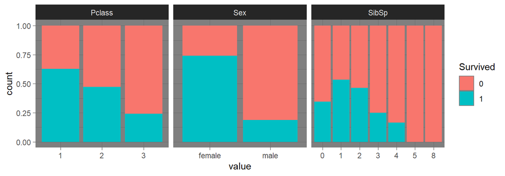

Based on the plot above, if we were to predict `Survived` variable, which of the shown predictors might be used as splitting rules?  
a. SibSp  
b. Pclass  
c. Sex  
d. Survived